# ECON6027 Project

## 2. Quadrat count analysis

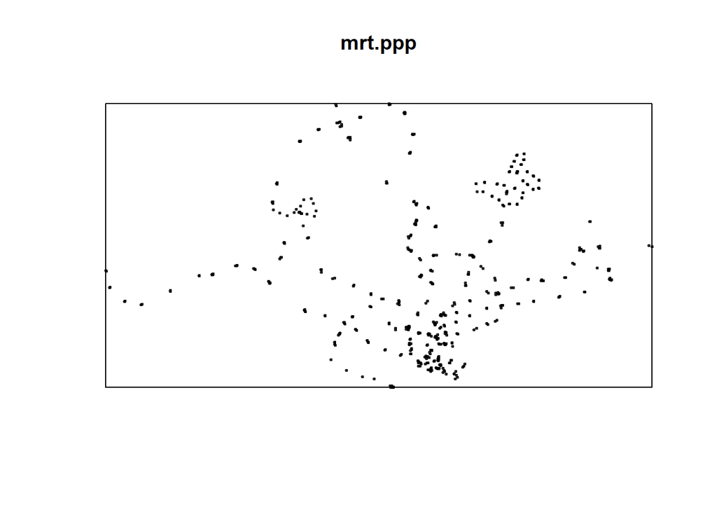

```r
mrt.ppp = as.ppp(mrt_lrt_exits_sf$geometry) #transform sf object to ppp
plot(mrt.ppp, pch=20, size=0.5)
```

```r
st_bbox(mrt_lrt_exits_sf)
```

```
##      xmin      ymin      xmax      ymax
##  6134.086 27499.697 45356.362 47865.923
```

```r
sg = st_union(sg_regions)
sg.owin = as.owin(sg)
class(sg.owin)
```

```
## [1] "owin"
```

```r
Window(mrt.ppp) = sg.owin
mrt.ppp # 563 points, no points out of the boundary
```

```
## Planar point pattern: 563 points
## window: polygonal boundary
## enclosing rectangle: [2667.54, 56396.44] x [15748.72, 50256.33] units
```

```r
table(duplicated(mrt.ppp)) # no duplicated entries, we can proceed
```

```
##
## FALSE
##   563
```

```r
qc_mrt = quadratcount(mrt.ppp, nx=10, ny=10)
class(qc_mrt)
```

```
## [1] "quadratcount" "table"
```

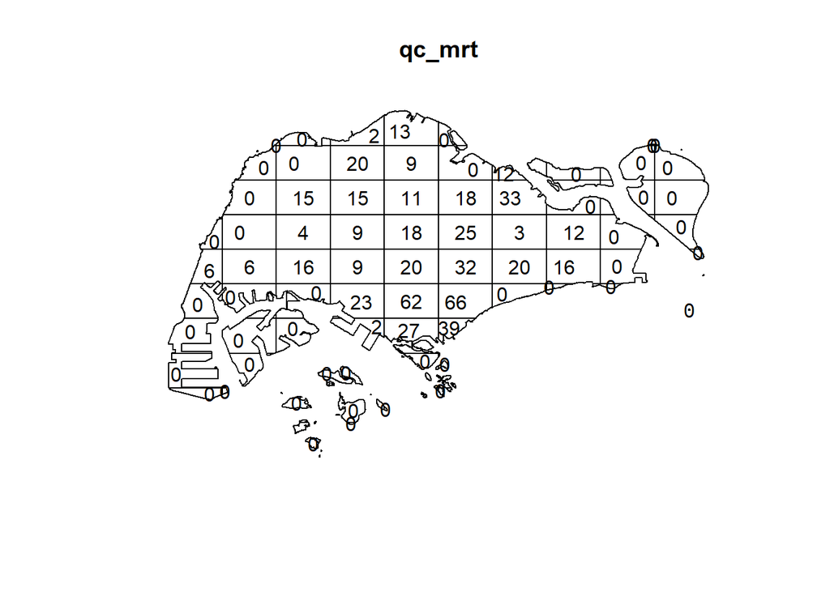

```r
plot(qc_mrt)
```

Chi2 (goodness of fit) test

```r
quad.test_mrt = quadrat.test(mrt.ppp, nx=10, ny=10)
```

## 3. Kernel density estimation

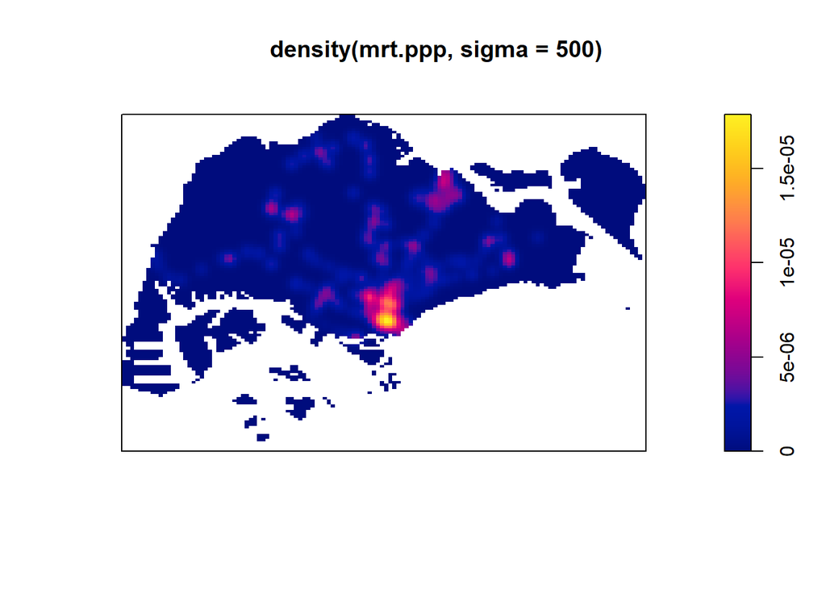

```r
plot(density(mrt.ppp, sigma=500))
```

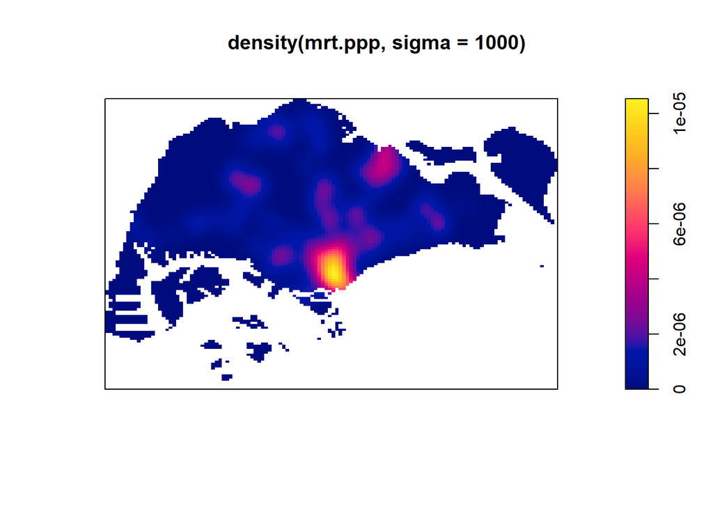

```r
plot(density(mrt.ppp, sigma=1000))
```

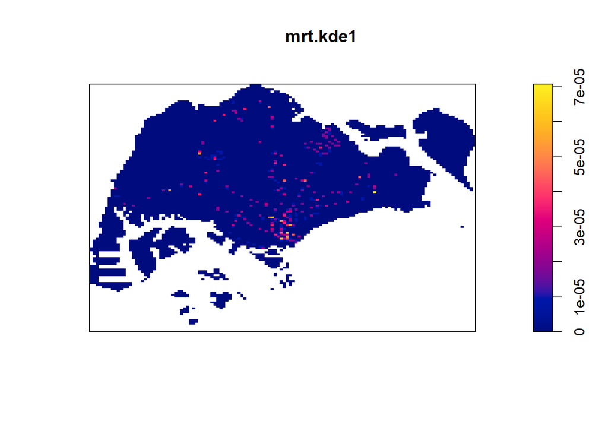

```r
mrt.bw1 = bw.diggle(mrt.ppp)
mrt.kde1 = density(mrt.ppp, sigma=mrt.bw1)
plot(mrt.kde1)
```

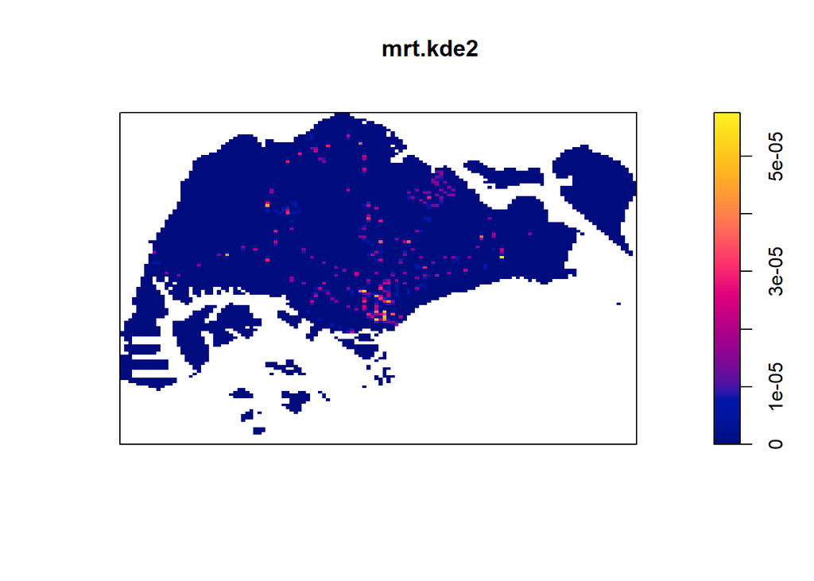

```r
mrt.bw2 = bw.ppl(mrt.ppp)
mrt.kde2 = density(mrt.ppp, sigma=mrt.bw2)
plot(mrt.kde2)
```

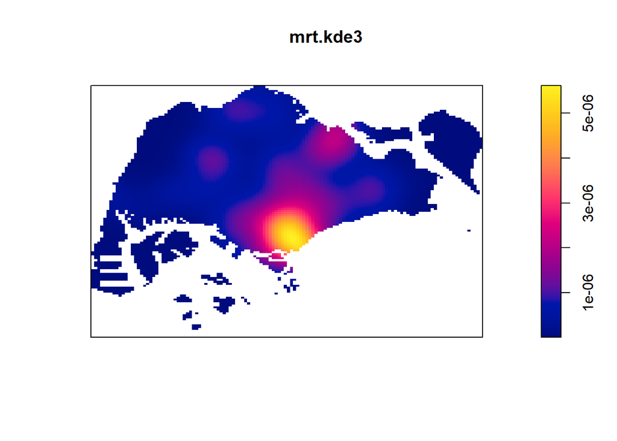

```r
mrt.bw3 = bw.scott(mrt.ppp)
mrt.kde3 = density(mrt.ppp, sigma=mrt.bw3)
plot(mrt.kde3)
```

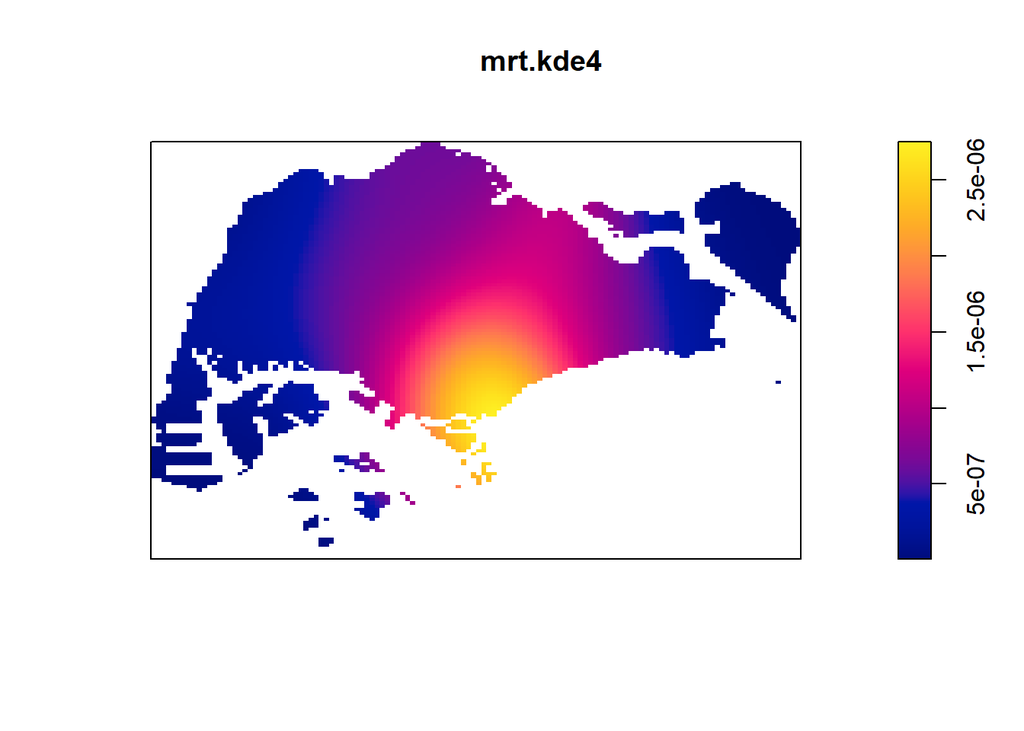

```r
mrt.bw4 = bw.CvL(mrt.ppp)
mrt.kde4 = density(mrt.ppp, sigma=mrt.bw4)
plot(mrt.kde4)
```

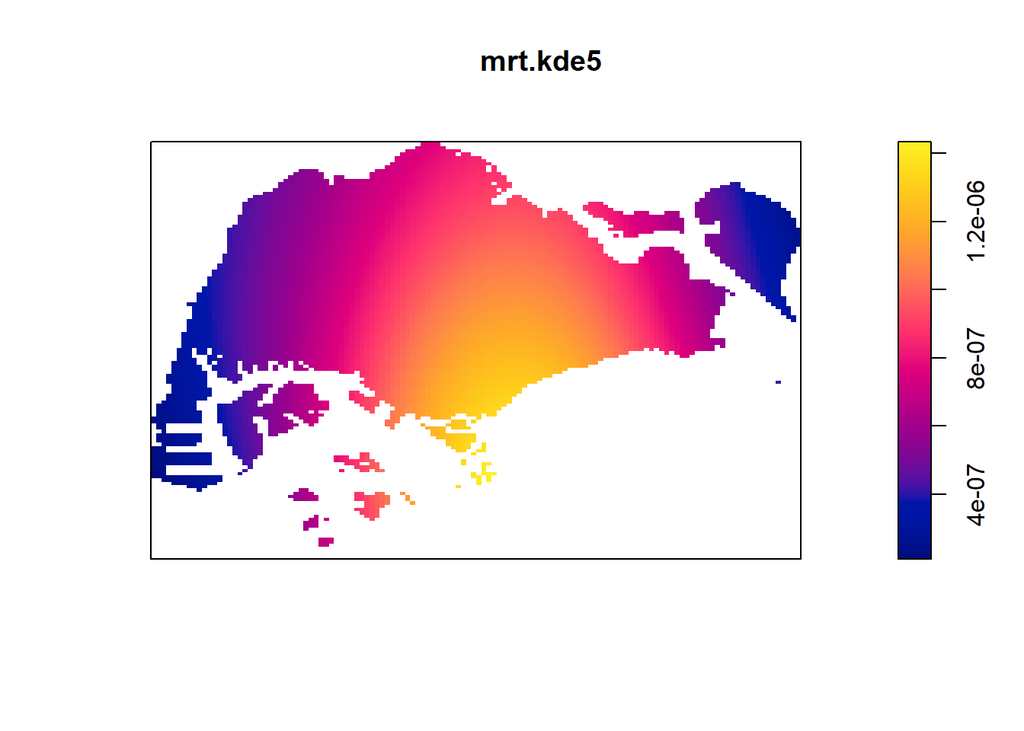

```r
mrt.bw5 = bw.frac(mrt.ppp)
mrt.kde5 = density(mrt.ppp, sigma=mrt.bw5)
plot(mrt.kde5)
```

## 4. Nearest neighbour distance analysis

```r
clarkevans(mrt.ppp, correction="none") #calculated index values less than 1 (r=0.1399807)
```

```
## [1] 0.1399807
```

```r
clarkevans.test(mrt.ppp, correction="none", alternative="less")
```

```
##
##  Clark-Evans test
##  No edge correction
##  Z-test
##
## data:  mrt.ppp
## R = 0.13998, p-value < 2.2e-16
## alternative hypothesis: clustered (R < 1)
```

```r
mrt.nnd = nndist(mrt.ppp, k=1)
summary(mrt.nnd)
```

```
##     Min.  1st Qu.   Median     Mean  3rd Qu.     Max.
##    3.474   32.250   51.796   82.484   91.776 1227.241
```

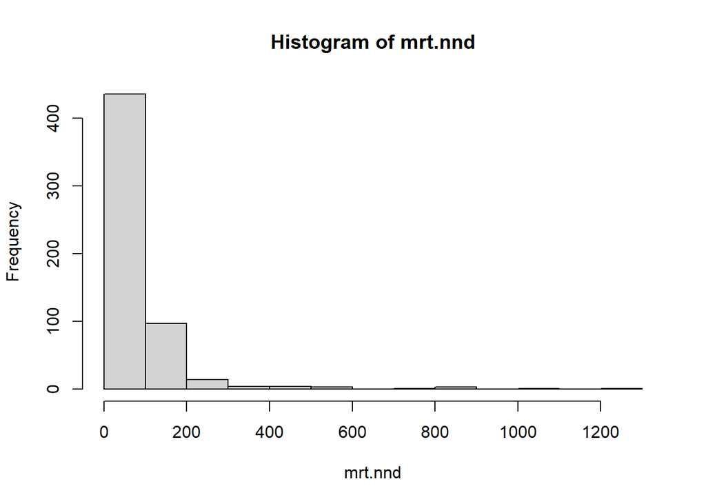

```r
hist(mrt.nnd)
```

```r
class(mrt.nnd)
```

```
## [1] "numeric"
```

```r
mrt.nnd = as.matrix(mrt.nnd)
```

## 6. Real World Analysis

Patching in population density by planning areas from [singstat.gov.sg](https://www.singstat.gov.sg/find-data/search-by-theme/population/geographic-distribution/latest-data). An area of consideration could be whether there are enough MRT/LRT in each planning area for residents of Singapore. This can be visualised by adding a layer of population density onto the Singapore planning area map with the MRT/LRT exit points.

```r
population_pa = read.csv("residentpopulation_2024.csv")
population_sf = inner_join(population_pa, sg_regions)
population_sf = st_as_sf(population_sf)
population_sf= st_transform(population_sf, 3414)
isTRUE(all.equal(st_crs(sg_regions), st_crs(population_sf))) #TRUE
```

```
## [1] TRUE
```

```r
population_sf$resident_2024_int = as.numeric(gsub(",", "", population_sf$resident_2024))
```

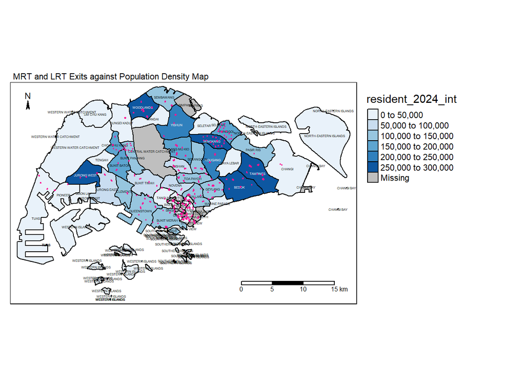

```r
population_density =
  tm_shape(population_sf) +
  tm_borders(col="black", lwd=1, lty=1) +
  tm_fill("resident_2024_int", lty=3, palette = "Blues") +
  tm_scale_bar(position = c("right", "bottom")) +
  tm_compass(position = c("left", "top"), size =0.8, text.size = 0.7) +
  tm_layout(main.title = "Population Density Map", legend.outside = T) + tm_text("PLN_AREA_N", size = 0.25)

mrt = population_density + tm_shape(mrt_lrt_exits_sf) +
  tm_dots(col = "deeppink", size=0.01) +
  tm_layout(main.title = "MRT and LRT Exits against Population Density Map", legend.outside = T, main.title.size = 0.7)
mrt #save as image: width = 2000, height = 1000 as SVG
```

From the map, we can see that there is a clustering of MRT/LRT stations at the central region with areas such as Newton, Orchard, River Valley, Downtown Core, Rochor and Outram despite the low population density. This is probably due to the region being the Central Business District of Singapore, with a high concentration of employment in the area.

To confirm this theory, we can plot another map against the workplace planning area density. The data for population workplace planning area was found from [singstat.gov.sg](https://tablebuilder.singstat.gov.sg/table/CT/17585).

```r
work_pa = read.csv("workplace_pa_travel.csv")
work_sf = inner_join(work_pa, sg_regions)
work_sf = st_as_sf(work_sf)
work_sf= st_transform(work_sf, 3414)
isTRUE(all.equal(st_crs(sg_regions), st_crs(work_sf))) #TRUE
```

```
## [1] TRUE
```

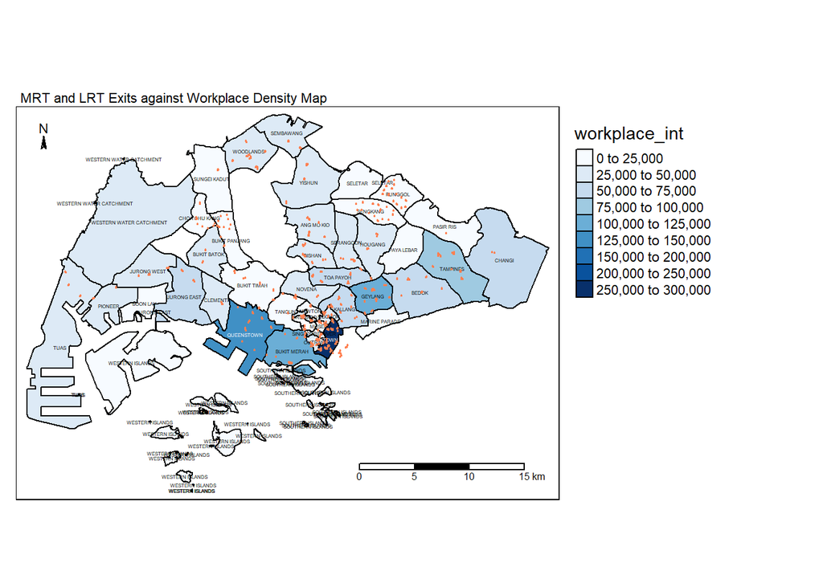

```r
work_sf$workplace_int = as.numeric(gsub(",", "", work_sf$Total))

workplace_density =
  tm_shape(work_sf) +
  tm_borders(col="black", lwd=1, lty=1) +
  tm_fill("workplace_int", lty=3, palette = "Blues", breaks = c(0, 25000, 50000, 75000, 100000, 125000, 150000, 200000, 250000, 300000)) +
  tm_scale_bar(position = c("right", "bottom")) +
  tm_compass(position = c("left", "top"), size =0.8, text.size = 0.7) +
  tm_layout(main.title = "Working Population Density Map", legend.outside = T) + tm_text("PLN_AREA_N", size = 0.25)

mrt_work = workplace_density + tm_shape(mrt_lrt_exits_sf) +
  tm_dots(col = "coral", size=0.01) +
  tm_layout(main.title = "MRT and LRT Exits against Workplace Density Map", legend.outside = T, main.title.size = 0.7)
mrt_work
```

We can see that with the combination of the residency population density and workplace population density, it gives us a better picture of how the Singapore government make plans for the buiding of MRT/LRT stations. The second map “mrt_work” showed how despite low residency population in the core central area, there is a high concentration of employees working in such areas. Hence, the planning of MRT/LRT in Singapore is sound, encompassing both ideas of residency population density and workplace population density.

Additional analysis: To confirm the connectivity of the MRT/LRT lines in Singapore, I utilised another dataset from [data.gov.sg](https://data.gov.sg/datasets?query=mrt&page=1&resultId=d_222bfc84eb86c7c11994d02f8939da8d). This dataset shows the rail line connectivity of the stations.

```r
mrt_2019 = geojson_sf("MasterPlan2019RailLinelayer.geojson")
mrt_2019_sf = st_transform(mrt_2019, crs=3414)
table(st_is_valid(mrt_2019_sf)) # all entries are valid
```

```
##
## TRUE
## 1366
```

```r
st_crs(mrt_2019_sf)$proj4string
```

```
## [1] "+proj=tmerc +lat_0=1.36666666666667 +lon_0=103.833333333333 +k=1 +x_0=28001.642 +y_0=38744.572 +ellps=WGS84 +towgs84=0,0,0,0,0,0,0 +units=m +no_defs"
```

```r
isTRUE(all.equal(st_crs(sg_regions), st_crs(mrt_2019_sf))) #TRUE, we can proceed
```

```
## [1] TRUE
```

```r
table(is.na(mrt_2019_sf$geometry)) # no station with empty coordinates
```

```
##
## FALSE
##  1366
```

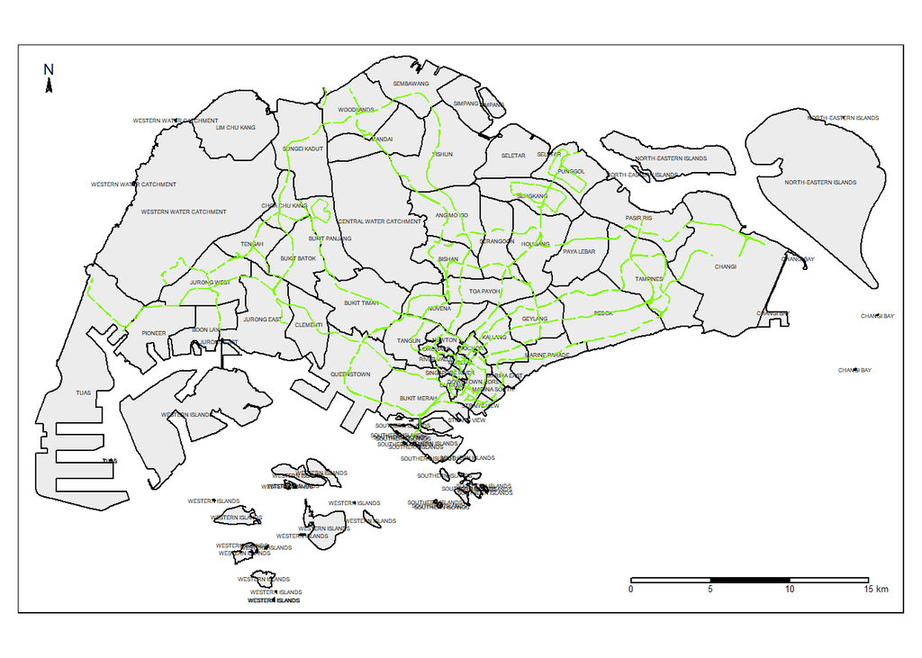

```r
sg_map_bg + tm_text("PLN_AREA_N", size = 0.25) + tm_shape(mrt_2019_sf) + tm_lines(col = "lawngreen")
```

From this map, we can see that while most of Singapore is pretty well connected via MRT/LRT, if there are future plans to develop the “Western Water Catchment” and “Lim Chu Kang” areas, there will be a need to further develop the rail lines in this areas to improve the connectivity. However, at this moment, these areas are used by the Singapore Armed Forces for live-firing training purposes, hence it is apt that there is low connectivity to the area to ensure low exposure to danger for the general public.

Another potential analysis could be a point analysis to check the distance analysis from a particular location to MRT/LRT stations. An example would be, if I am a potential buyer of a flat, I would want to see whether there are any nearby station exits to ensure MRT/LRT accessibility at my planned purchase location.

For example, I want to buy a flat at 760 PASIR RIS STREET 71 its coordinates in EPSG:4326 WGS 84 is 1.3764003,103.9335398 [source](https://www.onemap.gov.sg/). However, our maps are using CRS=3414, a localised Singapore coordinates system. Hence, I need to convert the coordinates to that of CRS=3414. I transformed the coordinates via [epsg.io](https://epsg.io/transform#s_srs=3414&t_srs=4326&ops=8886&x=NaN&y=NaN).

```r
flat = st_point(c(39153.3835467841, 39821.10189171739))
flat_point = st_sfc(flat)
attr = data.frame(Name="Intended flat purchase location")
flat_sf = st_sf(attr, geom = flat_point, crs = 3414)
st_crs(flat_sf)$proj
```

```
## [1] "tmerc"
```

```r
isTRUE(all.equal(st_crs(sg_regions), st_crs(mrt_lrt_exits_sf), st_crs(flat_sf)))
```

```
## [1] TRUE
```

```r
buffer = st_buffer(flat_sf, dist=1000)
tmap_leaflet(tm_shape(flat_sf) + tm_dots(col="pink") +
  tm_shape(buffer) + tm_borders(col = "blue") + tm_shape(mrt_lrt_exits_sf) + tm_dots())
```

[interactive chart not shown]

If I were to proceed with the purchase of this flat, I will need to consider other modes of public transportation (for example, bus) as there are no immediate MRT/LRT station exits within 1km. If having an MRT/LRT within walking distance is my top priority. This flat location will not be ideal.

If MRT/LRT accessibility is my top priority, I will need to purchase a flat in a location such as at 1D CANTONMENT ROAD THE PINNACLE @ DUXTON. Within 1km, there are many different MRT/LRT station exits. There are even station exits within 500m of the flat.

```r
flat2 = st_point(c(28908.94658009494, 28820.880891462275))
flat_point2 = st_sfc(flat2)
attr = data.frame(Name="Intended flat purchase location")
flat_sf2 = st_sf(attr, geom = flat_point2, crs = 3414)
st_crs(flat_sf2)$proj
```

```
## [1] "tmerc"
```

```r
isTRUE(all.equal(st_crs(sg_regions), st_crs(mrt_lrt_exits_sf), st_crs(flat_sf2)))
```

```
## [1] TRUE
```

```r
buffer2 = st_buffer(flat_sf2, dist=1000)
buffer2a = st_buffer(flat_sf2, dist=500)
tmap_leaflet(tm_shape(flat_sf2) + tm_dots(col="pink") +
               tm_shape(buffer2) + tm_borders(col = "blue") +
               tm_shape(buffer2a) + tm_borders(col = "cadetblue") +
               tm_shape(mrt_lrt_exits_sf) + tm_dots())
```

[interactive chart not shown]